# ggplot2 in R for biotrainee

## 2.5 箱式图

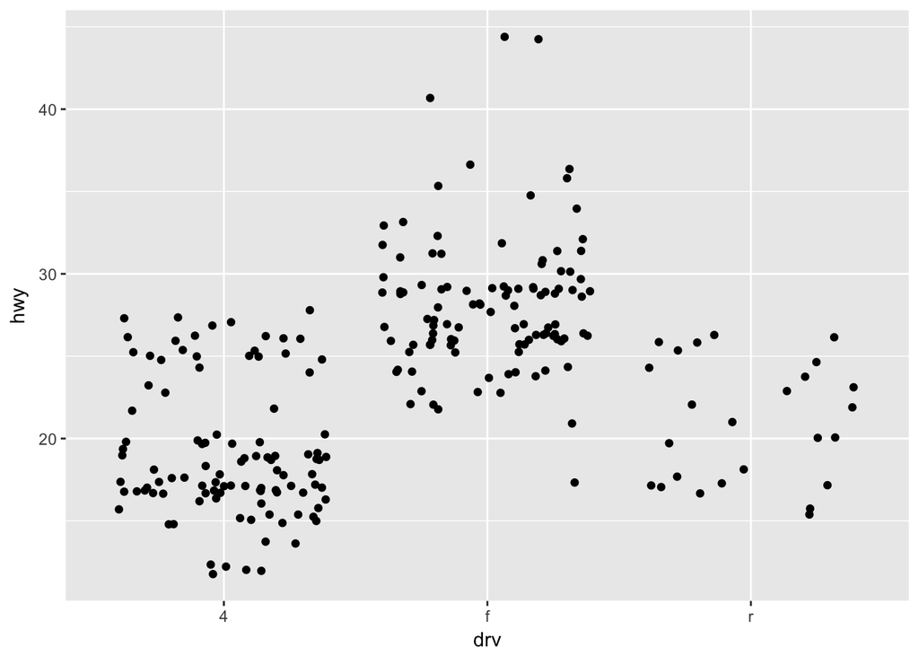

```r
ggplot(mpg, aes(drv, hwy)) + geom_jitter()
```

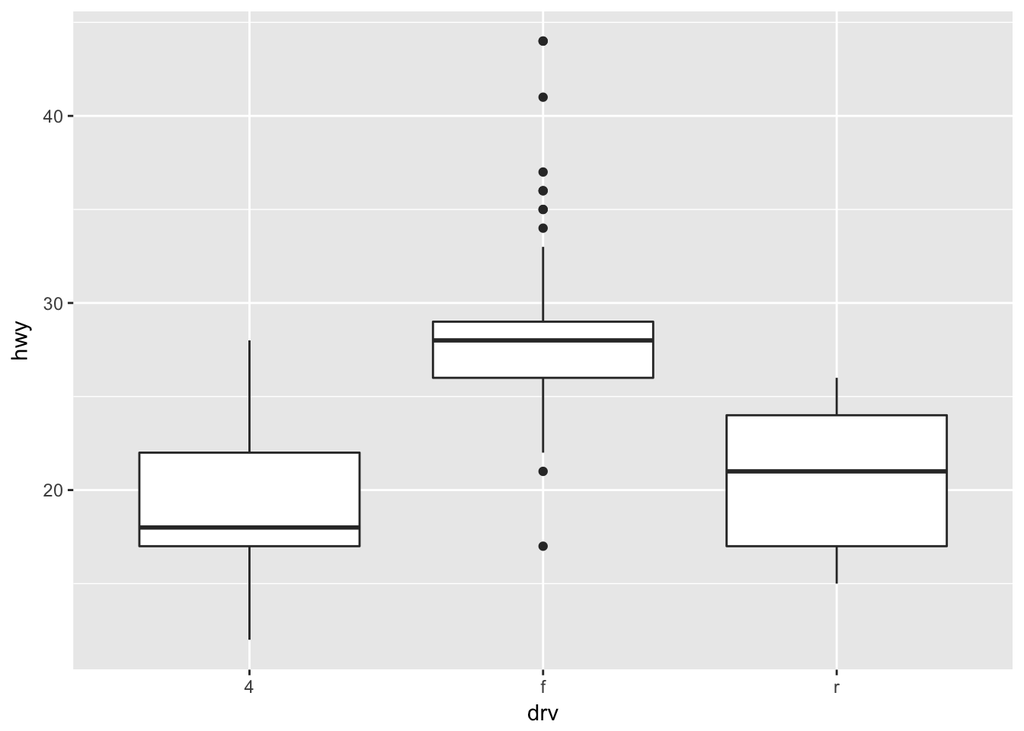

```r
ggplot(mpg, aes(drv, hwy))+ geom_boxplot()
```

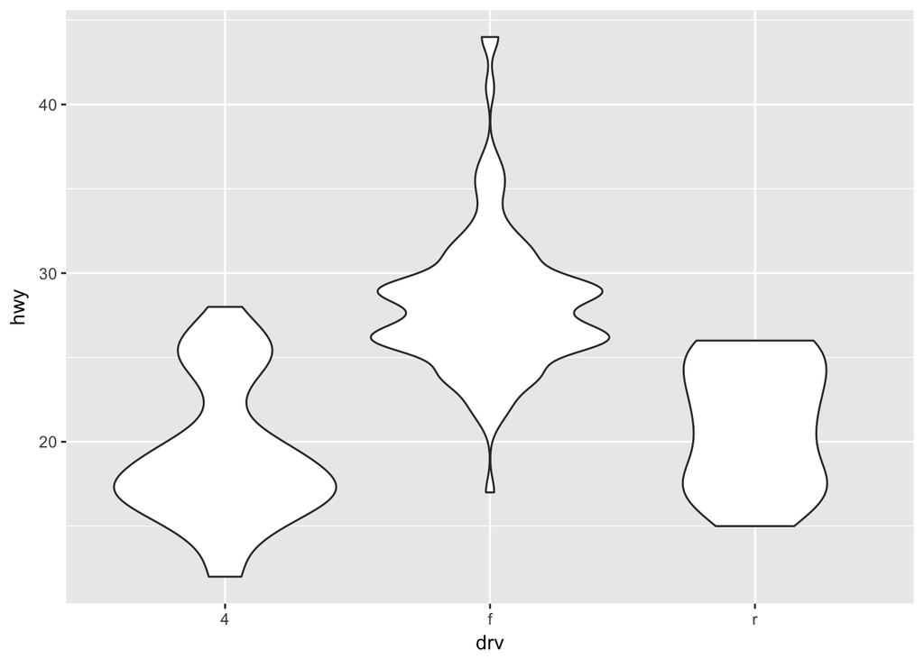

```r
ggplot(mpg, aes(drv, hwy)) + geom_violin()
```

三行代码对应三幅图，如果用“+“把上述代码合并，三张图即可叠加，即ggplot2以图层的模式，构建不同类型的统计图形。

## 2.6 直方图和频率多边形

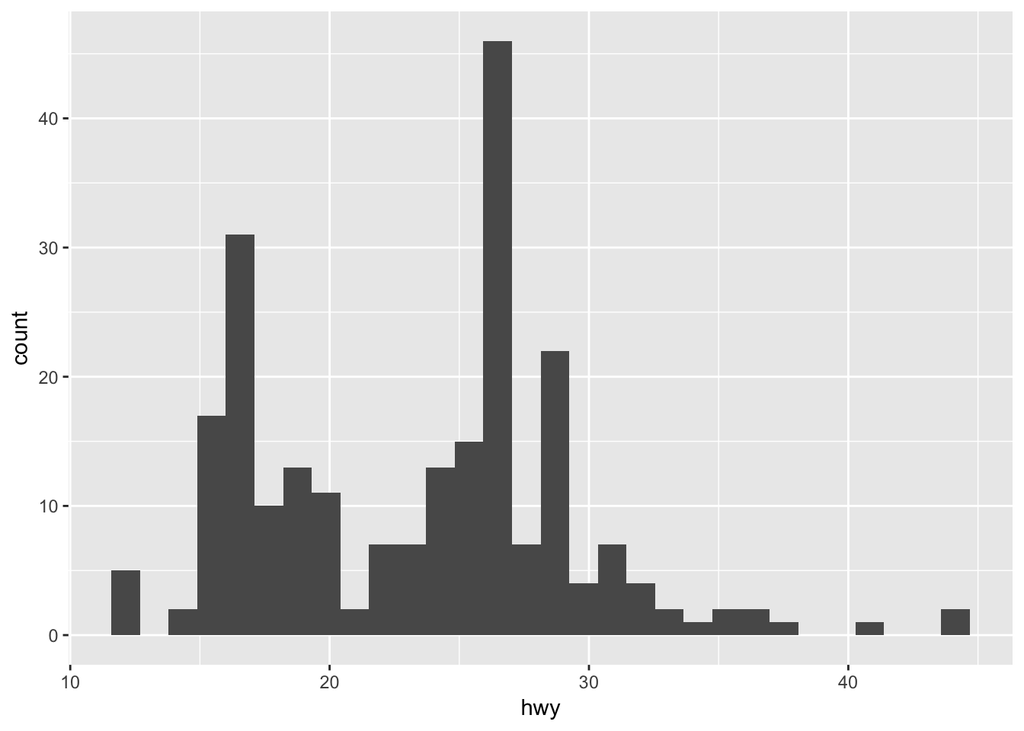

```r
ggplot(mpg, aes(hwy)) + geom_histogram()
```

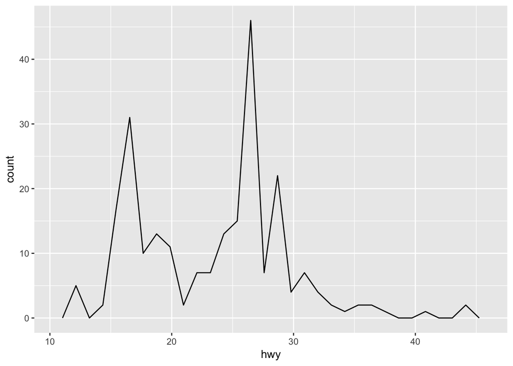

```r
ggplot(mpg, aes(hwy)) + geom_freqpoly()
```

## 2.7 柱状图

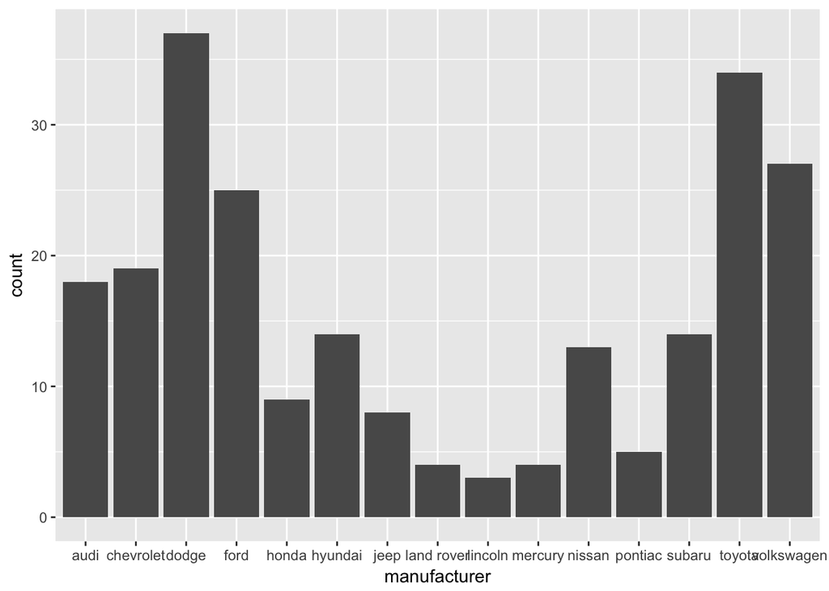

```r
ggplot(mpg, aes(manufacturer)) +
geom_bar()
```

## 2.8 时间序列图

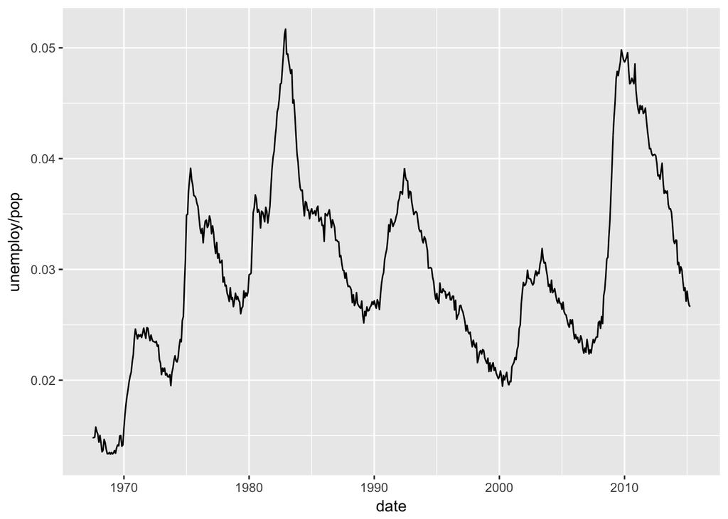

```r
ggplot(economics, aes(date, unemploy / pop)) +geom_line()
```

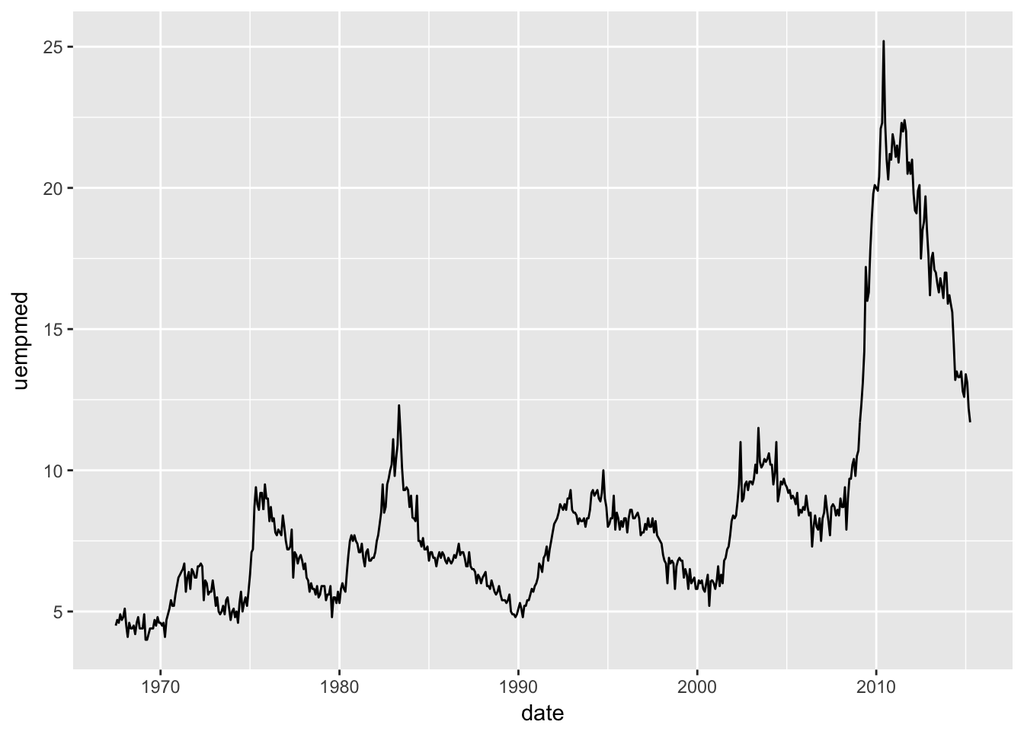

```r
ggplot(economics, aes(date, uempmed)) +geom_line()
```

## 2.9 路径图

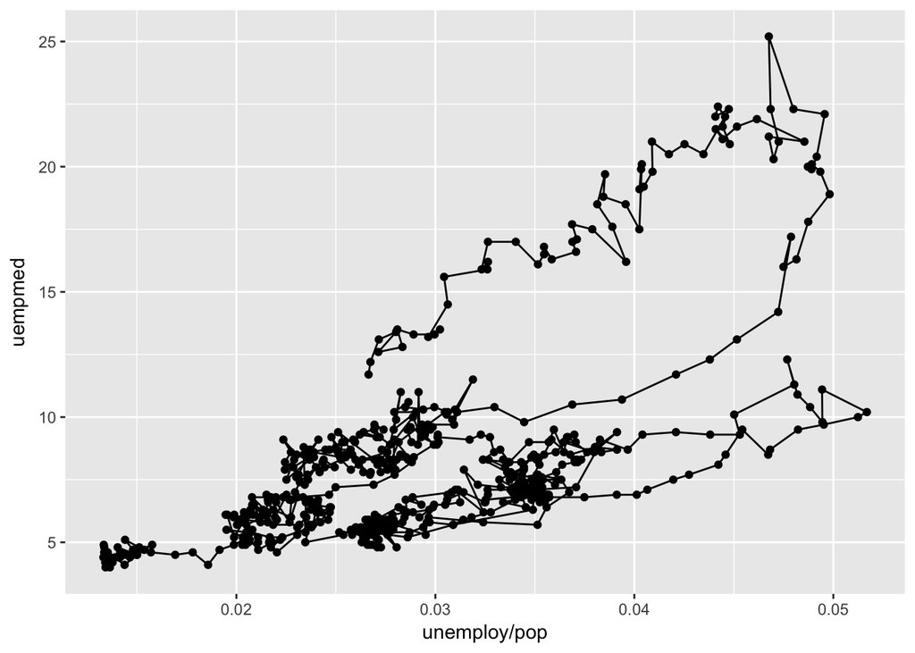

```r
ggplot(economics, aes(unemploy / pop, uempmed)) +
geom_path() +
geom_point()
```

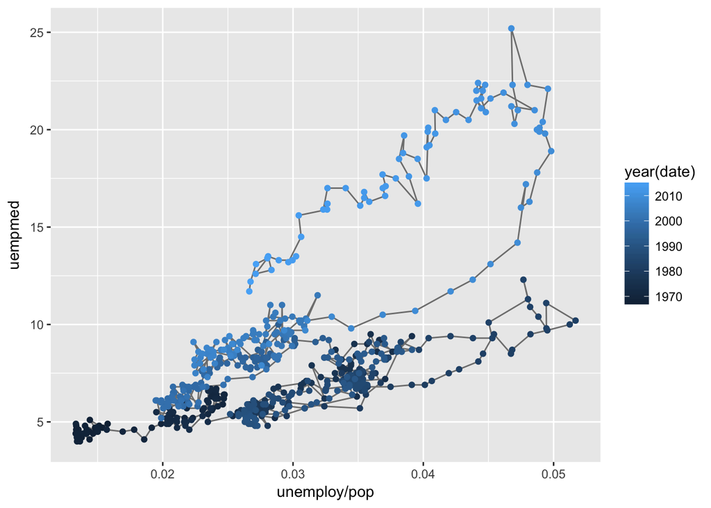

```r
year <- function(x) as.POSIXlt(x)$year + 1900
ggplot(economics, aes(unemploy / pop, uempmed)) +
geom_path(colour = "grey50") +
geom_point(aes(colour = year(date)))
```

选择aes () 函数，对连续的时间进行变量着色。

## 2.10 ggplot2其它统计图

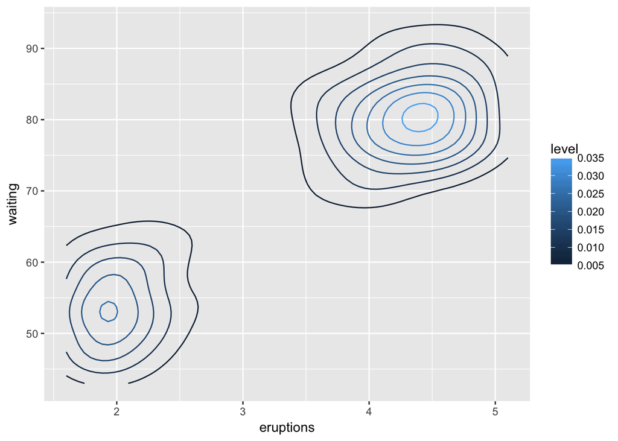

```r
ggplot(faithfuld, aes(eruptions, waiting)) +
geom_contour(aes(z = density, colour = ..level..))
```

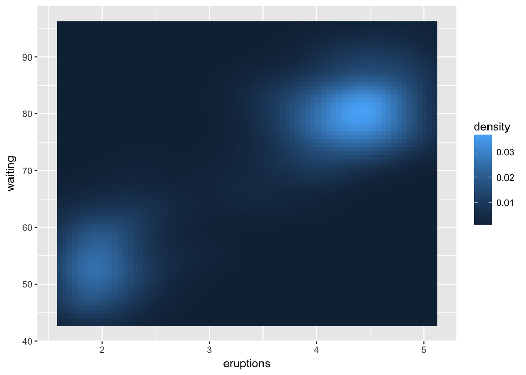

```r
ggplot(faithfuld, aes(eruptions, waiting)) +
geom_raster(aes(fill = density))
```

# 3 透明度设置

大量数据点覆盖堆积，将会掩盖数据趋势，可设置透明度加以区分。

```r
norm <- ggplot(df, aes(x, y)) + xlab(NULL) + ylab(NULL)
norm + geom_point (alpha = 1 / 3)
norm + geom_point (alpha = 1 / 5)
norm + geom_point (alpha = 1 / 10)
```

[output not shown]

# 4 主题设置

```r
theme_classic()
theme_minimal()
theme_economist()+ scale_colour_economist()
```

ggplot2更新很快，拥有大量函数，以实现多种统计图的绘制。

上述所列功能仅为抛砖引玉，详细函数列表和用法参见如下网址： http://ggplot2.tidyverse.org/reference/

# 5 无代码绘制ggplot2图

尽管ggplot2代码简洁，在不熟悉的前提下，依然会出现许多Bug，为此Keon-Woong Moon编写了Learn ggplot2 Shiny App，将代码的编写转化为图形模块的点击。

http://r-graph.com/

从主页中选择最近的服务器地址，即可打开在线ggplot2绘图网页。

加载数据后，用鼠标选择对应的变量，勾选需要绘制的统计图，即可一键出图。

页面左下方会显示相应的R代码，可以作为学习代码的教程。

```r
ggplot(data=acs,aes(x=Dx,y=age,fill=Dx))+
geom_point(position='jitter',size=0.3)+
geom_violin()+
geom_boxplot(fill='white',width=0.05,outlier.shape=1,outlier.size=16)+
stat_summary(geom='point',fun.y=mean,shape=23,size=3)+
theme(legend.position='none')
```

- Line 1：将变量数据映射到坐标系
- Line 2：添加散点图
- Line 3：添加小提琴图
- Line 4：添加箱式图
- Line 5：添加平均值
- Line 6：隐藏图例

Shiny App菜单栏的MultiPlot可实现上述4种图形依次保存和排列的功能，并快速输出。

plot提供了ggplot2两个扩展程序包——ggiraph和ggiraphExtra，用来绘制交互式的图形。除此之外，ggplot2拥有大量针对不同领域的扩展包。

# 6 ggplot2的扩展包

自从ggplot2巧妙地在R语言中实现了图形语法，以此为范例的程序包如雨后春笋般涌现。他们怀揣着神圣的总纲，站在巨人的肩上，将统计绘图的功能无限延伸。

```
animlnt：制作交互图形，增加询问，筛选链接等
ggthemes：提供扩展的图形风格主题
ggmap：提供在线地图服务模块
ggiraph：绘制交互式的ggplot图形
ggstance：实现常见图形的横向版本
GGally：绘制散点图矩阵
ggalt：添加额外的坐标轴、geoms等
ggforce：添加额外geoms等
ggrepel：避免图形标签重叠
ggraph：绘制网络状、树状等特定形状的图形
ggpmisc：光生物学相关扩展
ggbio：提供基因组学数据图形
geomnet：绘制网络状图形
ggExtra：绘制图形的边界直方图
gganimate：绘制动画图
plotROC：绘制交互式ROC曲线图
ggspectra：绘制光谱图
ggnetwork：网络状图形的geoms
ggradar：绘制雷达图
ggTimeSeries：时间序列数据可视化
ggtree：树图可视化
ggtern：绘制三元图
ggseas：季节调整工具
ggenealogy：浏览和展示系谱学数据
```

http://blog.sina.com.cn/s/blog_15dd952a70102wvuq.html

## 6.1 GGally

ggplot2分面得到的是完全相同的子集图形，而GGally扩展了该功能，能够绘制散点图矩阵，自定义矩阵中每一个图形元素。

http://ggobi.github.io/ggally/

尽管ggplot2默认条件下即可输出精美的图，但是其核心的图形语法并未限制于常规的统计图形，也未指定图形的外观，这极大地扩展了ggplot2绘图的范围和可能达到的极致美观。